# Project 2

STATS 220 Semester One, 2026

Armand Spencer

2026-03-31

## Introduction

The focus of this collection of data was to see how long the average journey took to get to university. Austin and I conducted measured how long the journey took to get to university, we also put down the start time of the journey and the mode of transportation used. Whenever we had a journey from university to home or vice versa, we would record the duration and the start time.

Guideline 2 requires to only ask for data we actually needed. So the created survey only asked three questions: Mode of Transport, Duration of Travel, and Start time. All three vectors of data were used to create visualizations and do some minor analysis. The form was made so that for Mode of Travel, you could only pick between Car and Bus - as that was the only modes of transportation we used. This made it so that any data points in this vector would all be relevant. Additionally, for Duration of Travel, the form explicitly ask “How many minutes did it take” and so only receives answers in number of minutes. Lastly, when we would put down start time of journeys, the form is formatted in a way so that we can only put in a time of day.

Guideline 3 specifics to consider respondents. We kept the data anonymous by not asking personal details about the respondent as we only actually needed transport data. For this data collection, any information regarding the person was deemed irrelevant and thus was not needed.

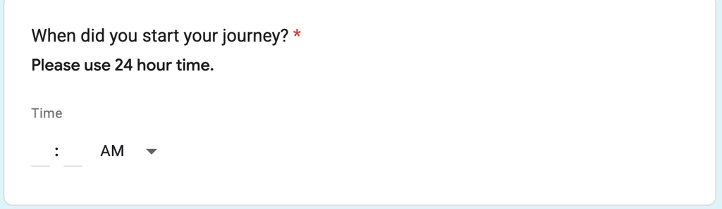

The data collected allows us to analyse patterns and relationships in our variables. We can view summaries, look at frequencies, create visualizations to paint us a picture of these data points. Especially with the travel mode, we can group datapoints by whether Car or Bus was used to view a relationship or a comparison between the two groups. From this we can draw conclusions about our data set using this information.

For what I did, I looked at summary values. Including looking at max and min travel time in our data set. I did try look at the mean, but it wouldn’t have meant too much unless I seperated the mean by travel mode. Which I did end up doing. compared mean travel time of Cars vs Bus by creating a new data frame that only shows the mean of Bus and Car. I also looked at bus vs car frequencies to see what was used more.

Some of the things we can learn from analyzing the data includes: 1. Comparing frequency of travel mode (Car or Bus) - As this tells us what travel mode is more preferred or more convenient, which later we can ask why each mode is preferrable 2. Comparing average journey times of Car vs Bus - We can learn what journey’s take longer and learn why this is 3. Seeing the differences between times of day and see how it influences journey duration - As we can learn how strongly duration of travel is influenced by traffic, and then also seeing which travel modes are influenced more by traffic

Form design and data collection for this project were completed as a group. My group members were Austin and Armand (me). [STATS 220 Project 2- Reporting Form](https://docs.google.com/forms/d/1Eo0QLtm6oK_MJ4Po4s_fG-UC4LZ9NFVAPpwcWR1eWPw/viewform?edit_requested=true)

## Dynamic Report

[My Amazing Dynamic Report](https://bluebirdchippies.github.io/stats220/Project%202/)

## Creativity

In terms of creativity, this project I tried to take a step further with the CSS and try to make the html page slightly more appealing to the eye. This involved doing a lot more research on what I can do. I looked for different fonts to use and saw what I liked and what looked good. I added the background to have a gradient colour wave. Utilising coolors.co to see what colours I saw looked nice.

Although there was not a lot of data points, I did some minor analysis on the data we had. This mainly included comparing standard deviations. The significance of this is due to the journey’s being constantly University -> Home or Home -> University, subsequently the distance of the journey remains constant. This means that comparing standard deviations is essentially us comparing whether traffic influences car travel or bus travel more. As the other main variable that influences duration of travel besides distance is traffic. Where the traffic is based upon what part of the day the travel is taking place. The only exception to this is weekends where people will not be clambering to get to work/school so there would be a lot less traffic. However as Austin or I don’t go to university of weekends. We can safely assume that the only other important factor on the standard deviation is the level of influence traffic has on travel mode.

And what I did find is that the standard deviation is lower for bus then it is for car

## Learning Reflection

Though it is not necessarily an idea, I was very pleased to learn about adding stuff into the ```{r} box. Such as fig.width and fig.height. This was very big for me because practically every time I looked at it I was always pretty confused with what I was looking at. Especially as whenever you open a new R markdown file, it shows a little explanation about markdown and the usage of {r} but I was still always perplexed about it until I started on this project.

I would like to do some data pre processing stuff. Like SQL stuff I think. From what I remember, I enjoyed similar stuff to that but I think I would definitely enjoy learning about the merges and that stuff.

Group work was pretty chill. We just had to make the survey and then put in data points together. It wasn’t exactly group work but it did serve to help our assignments being completed. I was a little behind so Austin had a headstart and gave the idea of what type of data we should look for. And as we both go to university, he figured transportation would be a good idea. And it was, but it was a bit awkward to analyse, but nonetheless still good!

Things that make group work good is reliable communication. Even if it is sloppy communication. As long as it remains consistent, it makes group work so much more enjoyable. As long as I am responding to Austin and he is responding to me then that is perfect

## Appendix

```r
library(tidyverse)

logged_data <- read_csv("https://docs.google.com/spreadsheets/d/e/2PACX-1vRetKKj9bMRzvsbYOusSWE0uw2oEJIxmDjFP6C2U79SCUlN05jlOH4OHHo5kVT4mpo5BdYi9q9NZh7w/pub?output=csv")

# testing
# view(logged_data)

# Renaming Variable Names
latest_data1 <- logged_data %>%
    rename(journey_mode = 2,
           duration_min = 3,
           journey_start_time = 4
           )

# Narrowing Dataframe to usable Vectors
latest_data <- latest_data1 %>%
  select( journey_mode,
          duration_min,
          journey_start_time)

view(latest_data)

# Viewing Summaries
max(latest_data$duration_min) # Longest Journey
min(latest_data$duration_min) # Shortest Journey


# Making new dataframe for mean values of duration
mean_data <- latest_data %>%
  group_by(journey_mode) %>%
  summarise(mean_duration = mean(duration_min, na.rm=TRUE))
view(mean_data)

# Plot Creation to compare mean Travel Times
ggplot(mean_data) +
         geom_col(aes(x =journey_mode,
                  y = mean_duration),
                  fill = "#DE8F6E") +
         labs(title = "Time of Transport by Travel Mode",
              x = "Journey Mode",
              y = "Mean Duration")

# Plot Creatio to compare Frequency of Travel Modes
ggplot(latest_data) +
  geom_bar(aes(x =journey_mode),
           fill = "#ADFC92") +
  labs(title = "Frequency of Travel Modes",
       x = "Travel Mode",
       y = "Frequency")
```

````r
---
title: My dynamic report
output: html_fragment
---

```{r setup, include=FALSE}
knitr::opts_chunk$set(echo=FALSE, message=FALSE, warning=FALSE, error=FALSE)
library(tidyverse)
```

```{css}

body {
  font-family: "Cal sans", "Segoe UI", Roboto, sans-serif;
  line-height: 1.6;
  max-width: 900px;
  margin: auto;
  padding: 20px;
  background: linear-gradient(135deg, #E0EFDA, #E18AD4);
  font-size: 15px;
}
p {
    font-family: "Cal sans", "Segoe UI", Roboto, sans-serif;
    font-size: 15px;
}

h1 {
  font-family: "Cal sans", "Segoe UI", Roboto, sans-serif;
  color: #2C3E50;
  font-weight: 600;
}

h2 {
  font_family: "Cal sans", "Segoe UI", Roboto, sans-serif;
  color: #2C3E50;
  font-weight: 600;
}

h3 {
  font-family: "Cal sans", "Segoe UI", Roboto, sans-serif;
  color: #2C3E50;
  font-weight: 600;
}

img {
  max-width: 100%;
  height: auto;
  display: block;
  margin:  auto;

}

```

## Comparing Travel Mode

In this minor study of travel mode, we measured three variables: Travel mode, Duration of Travel, and Time of Travel. After going through the data, I found there was not an easy way to utilise the Time of Travel variable without doing some major research into how to transform the vector into something usable. Subsequently in this document, we only actually used travel mode and duration of Travel as usable data.

```{r}
logged_data <- read_csv("https://docs.google.com/spreadsheets/d/e/2PACX-1vRetKKj9bMRzvsbYOusSWE0uw2oEJIxmDjFP6C2U79SCUlN05jlOH4OHHo5kVT4mpo5BdYi9q9NZh7w/pub?output=csv")

# testing
# view(logged_data)

# Renaming Variable Names
latest_data1 <- logged_data %>%
    rename(journey_mode = 2,
           duration_min = 3,
           journey_start_time = 4
           )

# Narrowing Dataframe to usable Vectors
latest_data <- latest_data1 %>%
  select( journey_mode,
          duration_min,
          journey_start_time)

# Viewing Summaries
max <- max(latest_data$duration_min) # Longest Journey
min <- min(latest_data$duration_min) # Shortest Journey

paste("In our data, we see that the longest journey took", max, "minutes, while the shortest journey took", min, "minutes.")

```

From our dataset, one thing we see is that the longest journey took 65 minutes as showed above and the shortest took 26 minutes. This is easily explained by traffic being the likely perpetrator here. The 26 minute journey most likely occurring either late at night or early in the morning. Whereas the 65 minute journey would have been smack bang during traffic hours.

```{r}
max_time <-latest_data %>%
  filter(duration_min == max(duration_min, na.rm = TRUE)) %>%
  select(journey_mode, duration_min, journey_start_time)

paste("The longest journey started at", max_time$journey_start_time[1], "and the travel mode was",  max_time$journey_mode[1])

```
Within further consideration, we will be using journey_start_time to see what time was the longest and shortest journey.

With further coding, the start time of travel associated with the longest journey is 7:22am as stated above. Lets find the start time for the shortest journey

```{r}
min_time <-latest_data %>%
  filter(duration_min == min(duration_min, na.rm = TRUE)) %>%
  select(journey_mode, duration_min, journey_start_time)

paste("The shortest journey started at", min_time$journey_start_time[1], "and the travel mode was",  min_time$journey_mode[1])

```
The shortest journey time start time is also consistent with traffic hours. Being situated at 9pm.



### Frequency of Travel Modes

```{r fig.width= 6, fig.height = 5}
# Plot Creation to compare Frequency of Travel Modes
ggplot(latest_data) +
  geom_bar(aes(x =journey_mode),
           fill = "#ADFC92") +
  labs(title = "Frequency of Travel Modes",
       x = "Travel Mode",
       y = "Frequency")

```

The figure above shows the frequency of travel modes. This data shows that during the week of data collection, they used a car nearly as frequently as using the bus. Car being used 8 times and Bus being used 10 times.

```{r, fig.width =6, fig.height = 5}
# Making new dataframe for mean values of duration
mean_data <- latest_data %>%
  group_by(journey_mode) %>%
  summarise(mean_duration = mean(duration_min, na.rm=TRUE))

# Plot Creation to compare mean Travel Times
ggplot(mean_data) +
         geom_col(aes(x =journey_mode,
                  y = mean_duration),
                  fill = "#DE8F6E") +
         labs(title = "Time of Transport by Travel Mode",
              x = "Journey Mode",
              y = "Mean Duration")

```
The second figure I created shows the mean travel time of Car vs Bus (as those were the only used travel options). This was done to show if there was a meaningful difference between the average time travelled by car vs on the bus.

As shown above, there is an observable difference. And it does show an interesting story. The reason being is that from above; we know that car as a travel mode includes both the longest journey and shortest journey. Yet the mean duration of both journey modes are quite similar, with bus being slightly longer. This tells us that the variance of bus journey is smaller then car. Which we will calculate right now!

```{r}

# creates subset of datapoints that used car
car_data <- latest_data %>%
  filter(journey_mode == "Car")
# creates subset of datapoints that used bus
bus_data <- latest_data %>%
  filter(journey_mode == "Bus")

# calculates standard deviation of both car and bus duration
sd_car <- round(sd(car_data$duration_min),2)
sd_bus <- round(sd(bus_data$duration_min),2)

paste("The standard deviation for Car is", sd_car, "while the standard deviation for Bus is", sd_bus)

```
Which the above calculation proves our statement correct. The standard deviation for Car is higher then Bus. This shows us that the journeys by bus are a lot more consistent in duration then it is for car from out dataset. However as the standard deviation for bus is still a sizable amount, we can infer that traffic and timing still does play a big factor in the duration of the journey. Although these factors are likely to influence car travel time to a stronger degree then it does for bus.

![](https://media1.tenor.com/m/AdaSVzqCxLIAAAAd/yugioh-anime.gif)
````